# Project Python Foundations: FoodHub Data Analysis

### Context

The number of restaurants in New York is increasing day by day. Lots of students and busy professionals rely on those restaurants due to their hectic lifestyles. Online food delivery service is a great option for them. It provides them with good food from their favorite restaurants. A food aggregator company FoodHub offers access to multiple restaurants through a single smartphone app.

The app allows the restaurants to receive a direct online order from a customer. The app assigns a delivery person from the company to pick up the order after it is confirmed by the restaurant. The delivery person then uses the map to reach the restaurant and waits for the food package. Once the food package is handed over to the delivery person, he/she confirms the pick-up in the app and travels to the customer's location to deliver the food. The delivery person confirms the drop-off in the app after delivering the food package to the customer. The customer can rate the order in the app. The food aggregator earns money by collecting a fixed margin of the delivery order from the restaurants.

### Objective

The food aggregator company has stored the data of the different orders made by the registered customers in their online portal. They want to analyze the data to get a fair idea about the demand of different restaurants which will help them in enhancing their customer experience. Suppose you are hired as a Data Scientist in this company and the Data Science team has shared some of the key questions that need to be answered. Perform the data analysis to find answers to these questions that will help the company to improve the business.

### Data Description

The data contains the different data related to a food order. The detailed data dictionary is given below.

### Data Dictionary

- order_id: Unique ID of the order
- customer_id: ID of the customer who ordered the food
- restaurant_name: Name of the restaurant
- cuisine_type: Cuisine ordered by the customer
- cost_of_the_order: Cost of the order
- day_of_the_week: Indicates whether the order is placed on a weekday or weekend (The weekday is from Monday to Friday and the weekend is Saturday and Sunday)
- rating: Rating given by the customer out of 5
- food_preparation_time: Time (in minutes) taken by the restaurant to prepare the food. This is calculated by taking the difference between the timestamps of the restaurant's order confirmation and the delivery person's pick-up confirmation.
- delivery_time: Time (in minutes) taken by the delivery person to deliver the food package. This is calculated by taking the difference between the timestamps of the delivery person's pick-up confirmation and drop-off information

### Let us start by importing the required libraries

```python
# Installing the libraries with the specified version.
!pip install numpy pandas matplotlib seaborn -q --user
```

**Note**:

- After running the above cell, kindly restart the runtime (for Google Colab) or notebook kernel (for Jupyter Notebook), and run all cells sequentially from the next cell.
- On executing the above line of code, you might see a warning regarding package dependencies. This error message can be ignored as the above code ensures that all necessary libraries and their dependencies are maintained to successfully execute the code in *this notebook*.

```python
# import libraries for data manipulation
import numpy as np
import pandas as pd

# import libraries for data visualization
import matplotlib.pyplot as plt
import seaborn as sns
```

### Understanding the structure of the data

```python
# Retrieve dataset is present in the Google Drive
from google.colab import drive
drive.mount('/content/drive')
```

```python
# Read the data
data = pd.read_csv('/content/drive/MyDrive/Python/foodhub_order.csv')
```

```python
# View the first 5 rows
data.head()
```

|  | order_id | customer_id | restaurant_name | cuisine_type | cost_of_the_order | day_of_the_week | rating | food_preparation_time | delivery_time |
| --- | --- | --- | --- | --- | --- | --- | --- | --- | --- |
| 0 | 1477147 | 337525 | Hangawi | Korean | 30.75 | Weekend | Not given | 25 | 20 |
| 1 | 1477685 | 358141 | Blue Ribbon Sushi Izakaya | Japanese | 12.08 | Weekend | Not given | 25 | 23 |
| 2 | 1477070 | 66393 | Cafe Habana | Mexican | 12.23 | Weekday | 5 | 23 | 28 |
| 3 | 1477334 | 106968 | Blue Ribbon Fried Chicken | American | 29.20 | Weekend | 3 | 25 | 15 |
| 4 | 1478249 | 76942 | Dirty Bird to Go | American | 11.59 | Weekday | 4 | 25 | 24 |

### **Question 1:** How many rows and columns are present in the data? [0.5 mark]

```python
# Print rows and columns
print("There are", data.shape[0], 'rows and', data.shape[1], "columns.")
```

```
There are 1898 rows and 9 columns.
```

Check the data types of the columns for the dataset

### **Question 2:** What are the datatypes of the different columns in the dataset? (The info() function can be used) [0.5 mark]

```python
# Information about different columns
data.info()
```

```
<class 'pandas.core.frame.DataFrame'>
RangeIndex: 1898 entries, 0 to 1897
Data columns (total 9 columns):
 #   Column                 Non-Null Count  Dtype
---  ------                 --------------  -----
 0   order_id               1898 non-null   int64
 1   customer_id            1898 non-null   int64
 2   restaurant_name        1898 non-null   object
 3   cuisine_type           1898 non-null   object
 4   cost_of_the_order      1898 non-null   float64
 5   day_of_the_week        1898 non-null   object
 6   rating                 1898 non-null   object
 7   food_preparation_time  1898 non-null   int64
 8   delivery_time          1898 non-null   int64
dtypes: float64(1), int64(4), object(4)
memory usage: 133.6+ KB
```

#### Observations:

There are 5 numerical columns in the data and 4 object type columns.

Rating is read as object type column but it should be a numerical column.

Changing Data Type of Rating to Numeric

```python
data['rating'].unique()
```

```
array(['Not given', '5', '3', '4'], dtype=object)
```

```python
# replacing "Not given" values with nan
data['rating_original'] = data['rating']

data['rating'] = data['rating'].replace(['Not given'],np.nan)

# changing the data type to float
data['rating'] = pd.to_numeric(data['rating'], errors='coerce')

data.info()
```

```
<class 'pandas.core.frame.DataFrame'>
RangeIndex: 1898 entries, 0 to 1897
Data columns (total 10 columns):
 #   Column                 Non-Null Count  Dtype
---  ------                 --------------  -----
 0   order_id               1898 non-null   int64
 1   customer_id            1898 non-null   int64
 2   restaurant_name        1898 non-null   object
 3   cuisine_type           1898 non-null   object
 4   cost_of_the_order      1898 non-null   float64
 5   day_of_the_week        1898 non-null   object
 6   rating                 1162 non-null   float64
 7   food_preparation_time  1898 non-null   int64
 8   delivery_time          1898 non-null   int64
 9   rating_original        1898 non-null   object
dtypes: float64(2), int64(4), object(4)
memory usage: 148.4+ KB
```

Adding a column total_time which is sum of food_preparation_time and delivery_time

```python
data['total_time'] = data['food_preparation_time'] + data['delivery_time']
data.info()
```

```
<class 'pandas.core.frame.DataFrame'>
RangeIndex: 1898 entries, 0 to 1897
Data columns (total 11 columns):
 #   Column                 Non-Null Count  Dtype
---  ------                 --------------  -----
 0   order_id               1898 non-null   int64
 1   customer_id            1898 non-null   int64
 2   restaurant_name        1898 non-null   object
 3   cuisine_type           1898 non-null   object
 4   cost_of_the_order      1898 non-null   float64
 5   day_of_the_week        1898 non-null   object
 6   rating                 1162 non-null   float64
 7   food_preparation_time  1898 non-null   int64
 8   delivery_time          1898 non-null   int64
 9   rating_original        1898 non-null   object
 10  total_time             1898 non-null   int64
dtypes: float64(2), int64(5), object(4)
memory usage: 163.2+ KB
```

Changed data type of rating to float and added total_time for better analysis.

Question 3: Are there any missing values in the data? If yes, treat them using an appropriate method. [1 mark]

```python
# Missing Values
data.isnull().sum()
```

|  | 0 |
| --- | --- |
| order_id | 0 |
| customer_id | 0 |
| restaurant_name | 0 |
| cuisine_type | 0 |
| cost_of_the_order | 0 |
| day_of_the_week | 0 |
| rating | 736 |
| food_preparation_time | 0 |
| delivery_time | 0 |
| rating_original | 0 |
| total_time | 0 |

**dtype:** int64

#### Observations:

Rating has missing values.

The missing values in the rating column came from the original 'Not given' entries. It should not be imputed (replaced with mean, median, or 0) for core data analysis purposes.

Replacing 'Not given' with 0 will introduce bias as a lack of feedback is not the same as low or average rating.

Using the appropriate method by leaving them as Nan. This ensures when we calculate the average rating we do consider orders with rating. No further transformation is required.

### **Question 4:** Check the statistical summary of the data. What is the minimum, average, and maximum time it takes for food to be prepared once an order is placed? [2 marks]

```python
# Describe Data
data.describe().T
```

|  | count | mean | std | min | 25% | 50% | 75% | max |
| --- | --- | --- | --- | --- | --- | --- | --- | --- |
| order_id | 1898.0 | 1.477496e+06 | 548.049724 | 1476547.00 | 1477021.25 | 1477495.50 | 1.477970e+06 | 1478444.00 |
| customer_id | 1898.0 | 1.711685e+05 | 113698.139743 | 1311.00 | 77787.75 | 128600.00 | 2.705250e+05 | 405334.00 |
| cost_of_the_order | 1898.0 | 1.649885e+01 | 7.483812 | 4.47 | 12.08 | 14.14 | 2.229750e+01 | 35.41 |
| rating | 1162.0 | 4.344234e+00 | 0.741478 | 3.00 | 4.00 | 5.00 | 5.000000e+00 | 5.00 |
| food_preparation_time | 1898.0 | 2.737197e+01 | 4.632481 | 20.00 | 23.00 | 27.00 | 3.100000e+01 | 35.00 |
| delivery_time | 1898.0 | 2.416175e+01 | 4.972637 | 15.00 | 20.00 | 25.00 | 2.800000e+01 | 33.00 |
| total_time | 1898.0 | 5.153372e+01 | 6.833603 | 35.00 | 47.00 | 52.00 | 5.600000e+01 | 68.00 |

#### Observations:

Minimum preparation time is 20.00 mins

Average preparation time is 27.37 mins(rounded to 2 decimals)

Maximum preparation time is 35.00 mins

Food preparation times across restaurants range from 20 to 35 mins, with an average of 27.37 minutes.

Total Time taken for orders vary from 35 mins to 68 mins which can be further analyzed for improvements.

### **Question 5:** How many orders are not rated? [1 mark]

```python
# Calculate Not Rated orders
not_rated_orders = data['rating'].isnull().sum()
print(not_rated_orders, 'orders are not rated.')
```

```
736 orders are not rated.
```

#### Observations:

Around 38.78% of all orders are not rated which can impact analysis. Foodhub should send in app reminders after delivery and give small incentives for feedback.

### Exploratory Data Analysis (EDA)

### **Question 6:** Explore all the variables and provide observations on their distributions. (Generally, histograms, boxplots, countplots, etc. are used for univariate exploration.) [9 marks]

1. Order ID

```python
# Check unique number of orders
data['order_id'].nunique()
```

```
1898
```

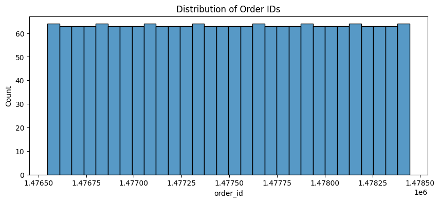

```python
plt.figure(figsize=(10,4))
sns.histplot(data['order_id'],bins=30)
plt.title('Distribution of Order IDs')
plt.show()
```

Observations: There are total 1898 unique number of orders Each order has a unique ID, so the histogram is roughly uniform. There are no duplicates or missing order ids.

1. Customer ID

```python
# Check unique number of customers
data['customer_id'].nunique()
```

```
1200
```

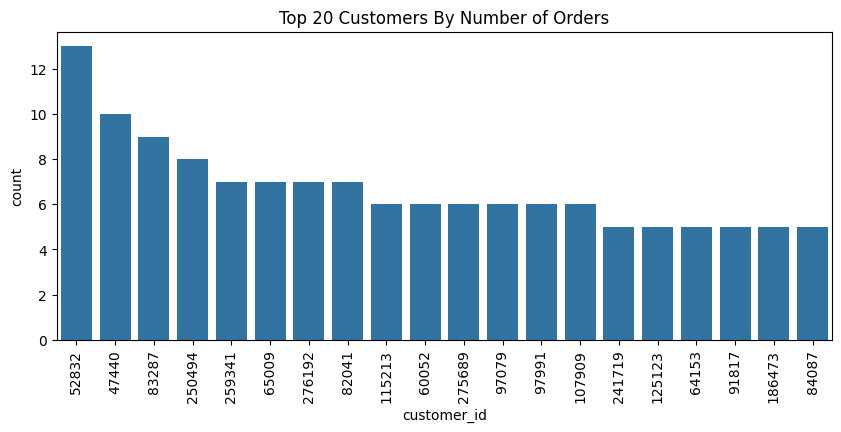

```python
plt.figure(figsize=(10,4))
sns.countplot(x= data['customer_id'], order=data['customer_id'].value_counts().index[:20])
plt.title('Top 20 Customers By Number of Orders')
plt.xticks(rotation=90)
plt.show()
```

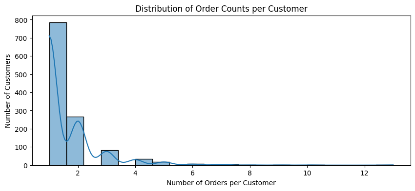

```python
# Distribution of order counts per customer
plt.figure(figsize=(10,4))
sns.histplot(data['customer_id'].value_counts(),bins=20, kde=True)
plt.xlabel('Number of Orders per Customer')
plt.ylabel('Number of Customers')
plt.title('Distribution of Order Counts per Customer')
plt.show()
```

Observations: Total of 1200 customers have placed 1898 orders. Some customers placed multiple orders . Top customers have 6-13 orders. Majority of customers placed only 1 order, indicating many one-time users. This helps identify loyal customers for targeted promotions.

1. Restaurant Name

```python
data['restaurant_name'].nunique()
```

```
178
```

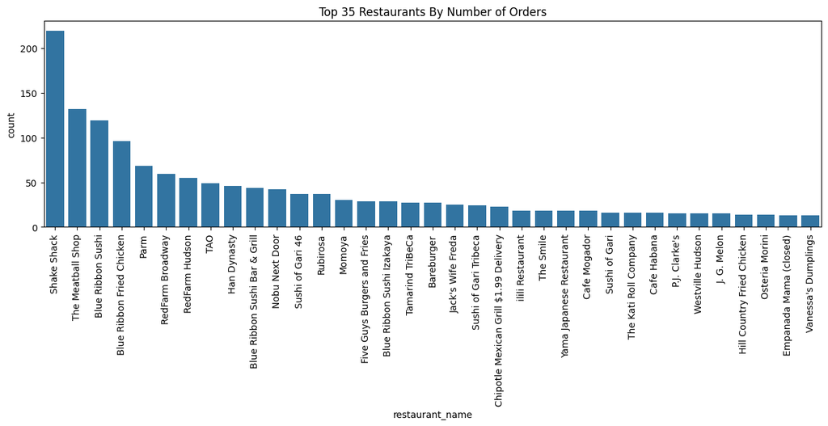

```python
# Count plot
plt.figure(figsize=(15,4))
sns.countplot(x= data['restaurant_name'], order=data['restaurant_name'].value_counts().index[0:35])
plt.title('Top 35 Restaurants By Number of Orders')
plt.xticks(rotation=90)
plt.show()
```

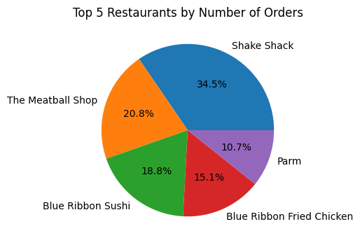

```python
# Pie chart of top 5 restaurants
top_restaurants = data['restaurant_name'].value_counts().head(5)
plt.figure(figsize=(10,4))
plt.pie(top_restaurants, labels=top_restaurants.index, autopct='%1.1f%%')
plt.title('Top 5 Restaurants by Number of Orders')
plt.show()
```

Observations There are total of 178 unique restaurants.

Majority of the business comes from few restaurants.

1. Cuisine Type

```python
# Unique Cuisine types
data['cuisine_type'].nunique()
```

```
14
```

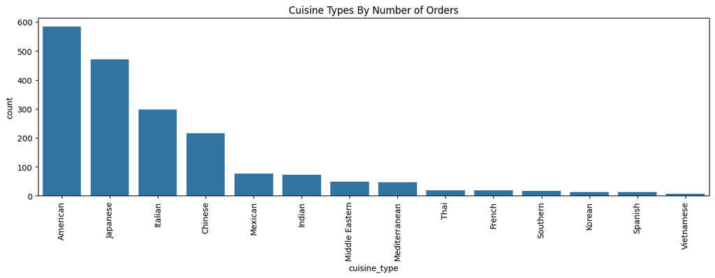

```python
# Count plot
plt.figure(figsize=(15,4))
sns.countplot(x= data['cuisine_type'], order=data['cuisine_type'].value_counts().index)
plt.title('Cuisine Types By Number of Orders')
plt.xticks(rotation=90)
plt.show()
```

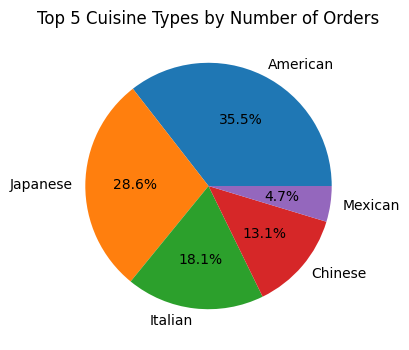

```python
#Pie chart of top 5 Cusine Types
top_cuisines = data['cuisine_type'].value_counts().head(5)
plt.figure(figsize=(10,4))
plt.pie(top_cuisines, labels=top_cuisines.index, autopct='%1.1f%%')
plt.title('Top 5 Cuisine Types by Number of Orders')
plt.show()
```

Observations

There are total of 14 different types of cuisines.

Cuisines like Korean, Spanish , Vietnamese have lowest orders.

1. Cost Of Order

```python
# unique costs
data['cost_of_the_order'].nunique()
```

```
312
```

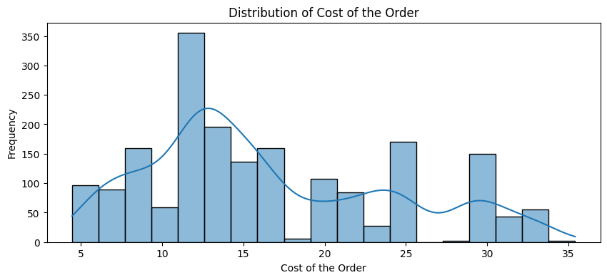

```python
# Histogram + KDE
plt.figure(figsize=(10,4))
sns.histplot(data['cost_of_the_order'], kde=True)
plt.xlabel('Cost of the Order')
plt.ylabel('Frequency')
plt.title('Distribution of Cost of the Order')
plt.show()
```

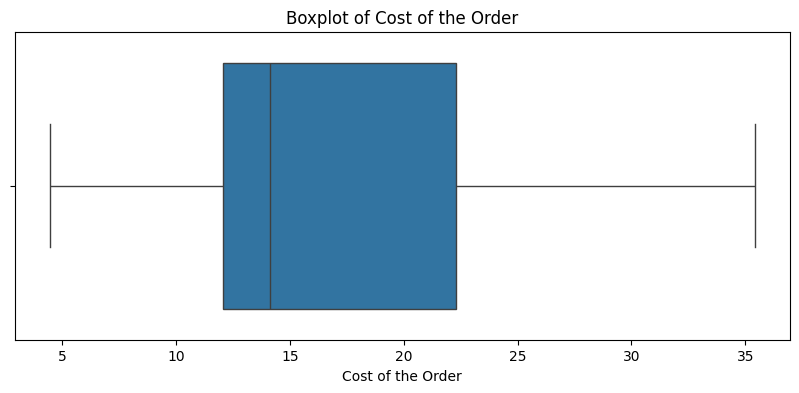

```python
#Boxplot
plt.figure(figsize=(10,4))
sns.boxplot(x=data['cost_of_the_order'], orient='h')
plt.xlabel('Cost of the Order')
plt.title('Boxplot of Cost of the Order')
plt.show()
```

Observations

Cost is Right Skewed which means most people order low cost.

Histogram shows multiple peaks, suggesting distinct price points or customer segments.

The distribution includes a few high cost orders that contribute to the skew.

1. Day of Week

```python
# unique values
data['day_of_the_week'].nunique()
```

```
2
```

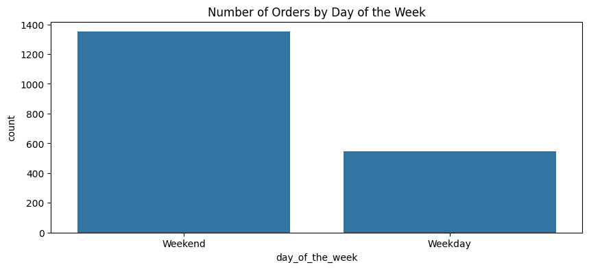

```python
#count plot
plt.figure(figsize=(10,4))
sns.countplot(x= data['day_of_the_week'])
plt.title('Number of Orders by Day of the Week')
plt.show()
```

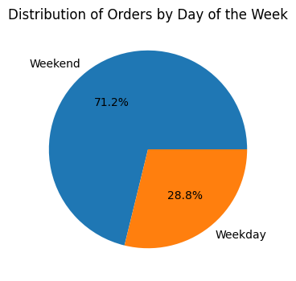

```python
# piechart
day_counts = data['day_of_the_week'].value_counts()
plt.figure(figsize=(10,4))
plt.pie(day_counts, labels=day_counts.index, autopct='%1.1f%%')
plt.title('Distribution of Orders by Day of the Week')
plt.show()
```

Observations More people order food on the weekends than the weekdays

71.2 % people order food on Weekends and 28.8% people order food on weekdays

Weekends has massive demand.

1. Rating

```python
# unique rating
data['rating'].nunique()
```

```
3
```

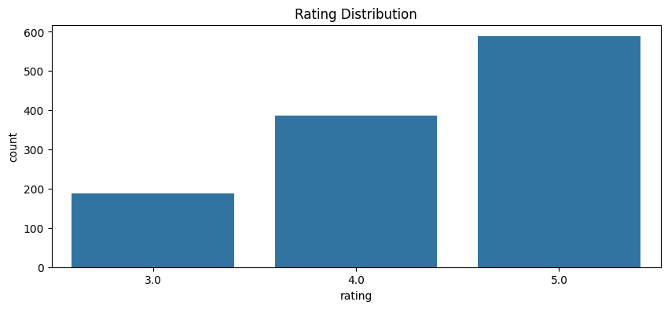

```python
# count plot
plt.figure(figsize=(10,4))
sns.countplot(x= data['rating'])
plt.title('Rating Distribution')
plt.show()
```

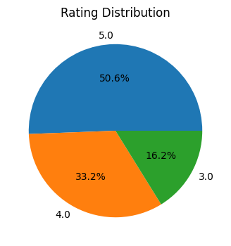

```python
# piechart
rating_counts = data['rating'].value_counts()
plt.figure(figsize=(10,4))
plt.pie(rating_counts, labels=rating_counts.index, autopct='%1.1f%%')
plt.title('Rating Distribution')
plt.show()
```

Observations

Most people who gave rating rated it above 3.

31.0% people rated 5 and 20.3% rated 4 and 9.9% rated 3

38.8% people did not rate.

There are no 1 star or 2 star rating. This could imply high service quality or that lowest ratings are not being captured or recorded properly.

1. Food Preparation Time

```python
#unique values
data['food_preparation_time'].nunique()
```

```
16
```

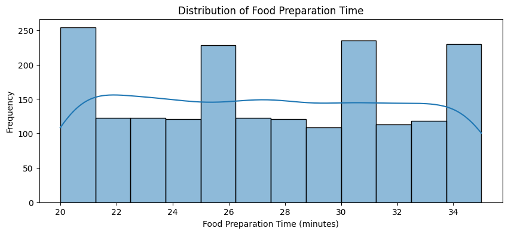

```python
#histplot
plt.figure(figsize=(10,4))
sns.histplot(data['food_preparation_time'], kde=True)
plt.xlabel('Food Preparation Time (minutes)')
plt.ylabel('Frequency')
plt.title('Distribution of Food Preparation Time')
plt.show()
```

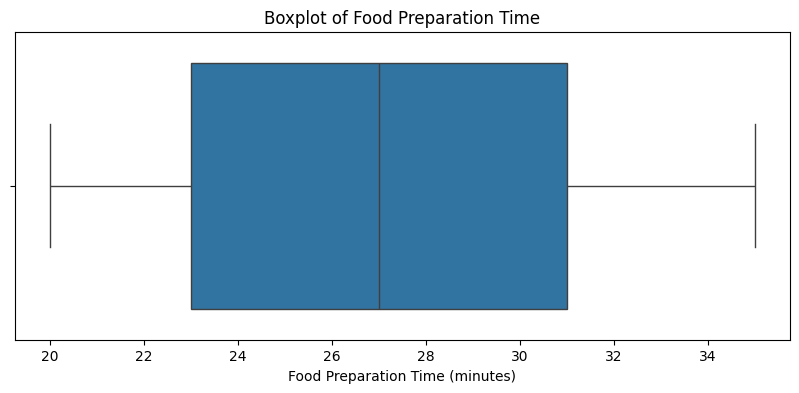

```python
#boxplot
plt.figure(figsize=(10,4))
sns.boxplot(x=data['food_preparation_time'], orient='h')
plt.xlabel('Food Preparation Time (minutes)')
plt.title('Boxplot of Food Preparation Time')
plt.show()
```

Observations

Preparation time is fairly consistent and takes between 20-35 mins.

1. Delivery Time

```python
#unique values
data['delivery_time'].nunique()
```

```
19
```

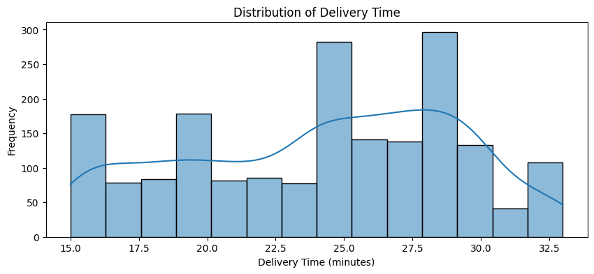

```python
#histplot
plt.figure(figsize=(10,4))
sns.histplot(data['delivery_time'], kde=True)
plt.xlabel('Delivery Time (minutes)')
plt.ylabel('Frequency')
plt.title('Distribution of Delivery Time')
plt.show()
```

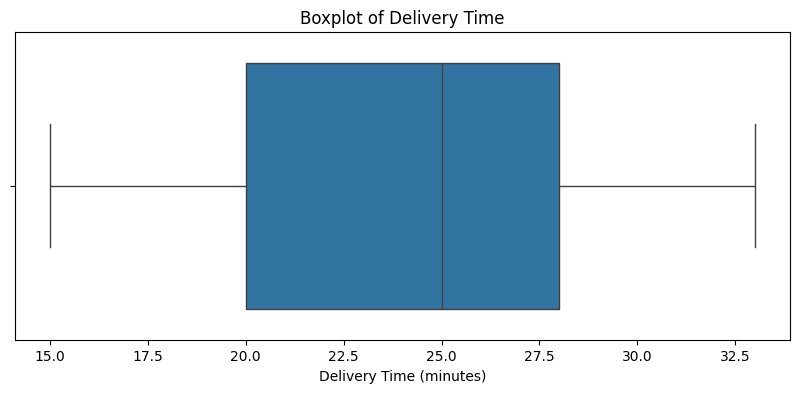

```python
#boxplot
plt.figure(figsize=(10,4))
sns.boxplot(x=data['delivery_time'], orient='h')
plt.xlabel('Delivery Time (minutes)')
plt.title('Boxplot of Delivery Time')
plt.show()
```

Observations

1. Total Time

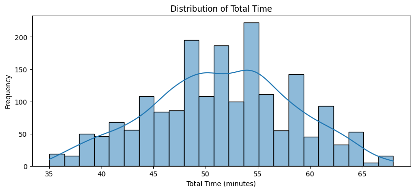

```python
#histplot
plt.figure(figsize=(10,4))
sns.histplot(data['total_time'], kde=True)
plt.xlabel('Total Time (minutes)')
plt.ylabel('Frequency')
plt.title('Distribution of Total Time')
plt.show()
```

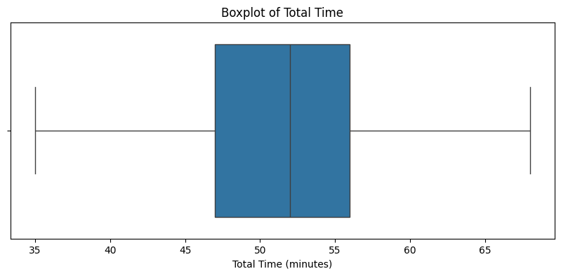

```python
#boxplot
plt.figure(figsize=(10,4))
sns.boxplot(x=data['total_time'], orient='h')
plt.xlabel('Total Time (minutes)')
plt.title('Boxplot of Total Time')
plt.show()
```

Observations: Slightly left skewed clustered around the median(52 mins) The total waiting time for customers ranges from 35 to 68 minutes. Customer's total wait time is relatively consistent.

### **Question 7**: Which are the top 5 restaurants in terms of the number of orders received? [1 mark]

```python
# Write the code here
top_restaurants = data['restaurant_name'].value_counts().head(5)
top_restaurants
```

| restaurant_name | count |
| --- | --- |
| Shake Shack | 219 |
| The Meatball Shop | 132 |
| Blue Ribbon Sushi | 119 |
| Blue Ribbon Fried Chicken | 96 |
| Parm | 68 |

**dtype:** int64

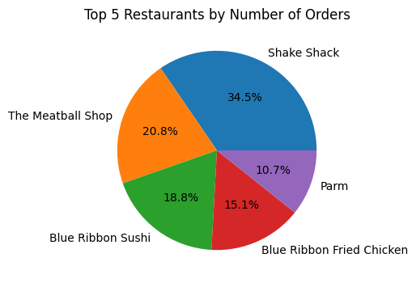

```python
#pie chart for top 5
plt.figure(figsize=(10,4))
plt.pie(top_restaurants, labels=top_restaurants.index, autopct='%1.1f%%')
plt.title('Top 5 Restaurants by Number of Orders')
plt.show()
```

### **Question 8**: Which is the most popular cuisine on weekends? [1 mark]

```python
# Write the code here
weekend_orders = data[data['day_of_the_week'] == 'Weekend']
popular_cuisine = weekend_orders['cuisine_type'].value_counts().idxmax()
popular_cuisine
```

```
'American'
```

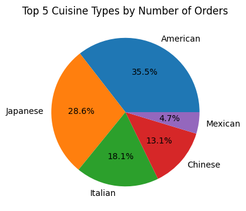

```python
#Pie chart for top 5 cusisine
top_cuisines = data['cuisine_type'].value_counts().head(5)
plt.figure(figsize=(10,4))
plt.pie(top_cuisines, labels=top_cuisines.index, autopct='%1.1f%%')
plt.title('Top 5 Cuisine Types by Number of Orders')
plt.show()
```

### **Question 9**: What percentage of the orders cost more than 20 dollars? [2 marks]

```python
# Write the code here
high_cost_orders = data[data['cost_of_the_order'] > 20]
high_cost_percentage = (len(high_cost_orders) / len(data)) * 100
high_cost_percentage
```

```
29.24130663856691
```

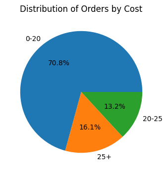

```python
# Draw a pie chart showing 0-20 , 20-25 , 25+ dollars
data['cost_category'] = pd.cut(data['cost_of_the_order'], bins=[0, 20, 25, float('inf')], labels=['0-20', '20-25', '25+'])
cost_counts = data['cost_category'].value_counts()
plt.figure(figsize=(10,4))
plt.pie(cost_counts, labels=cost_counts.index, autopct='%1.1f%%')
plt.title('Distribution of Orders by Cost')
plt.show()
```

#### Observations:

70% of the orders fall in low category which is 0-20 dollars. Only 29.24% orders are above 20 dollars which shows opportunity to focus on customers that spend more for more commission.

### **Question 10**: What is the mean order delivery time? [1 mark]

```python
# Write the code here
mean_delivery_time = data['delivery_time'].mean()
mean_delivery_time
print(f"The mean order delivery time is {mean_delivery_time:.2f} minutes.")
```

```
The mean order delivery time is 24.16 minutes.
```

#### Observations:

Mean order delivery time is pretty consistent between 24.16 minutes.

### **Question 11:** The company has decided to give 20% discount vouchers to the top 3 most frequent customers. Find the IDs of these customers and the number of orders they placed. [1 mark]

```python
# Write the code here
top_customers = data['customer_id'].value_counts().head(3)
top_customers
number_of_orders = data[data['customer_id'].isin(top_customers.index)]['customer_id'].value_counts()
number_of_orders
for customer_id, count in number_of_orders.items():
    print(f"Customer ID: {customer_id}, Number of Orders: {count}")
```

```
Customer ID: 52832, Number of Orders: 13
Customer ID: 47440, Number of Orders: 10
Customer ID: 83287, Number of Orders: 9
```

#### Observations:

Top 3 customers have ordered 13,10 and 9 orders respectively.

There are loyal customers and rewarding them can further improve business.

### **Question 12**: Perform a multivariate analysis to explore relationships between the important variables in the dataset. (It is a good idea to explore relations between numerical variables as well as relations between numerical and categorical variables) [10 marks]

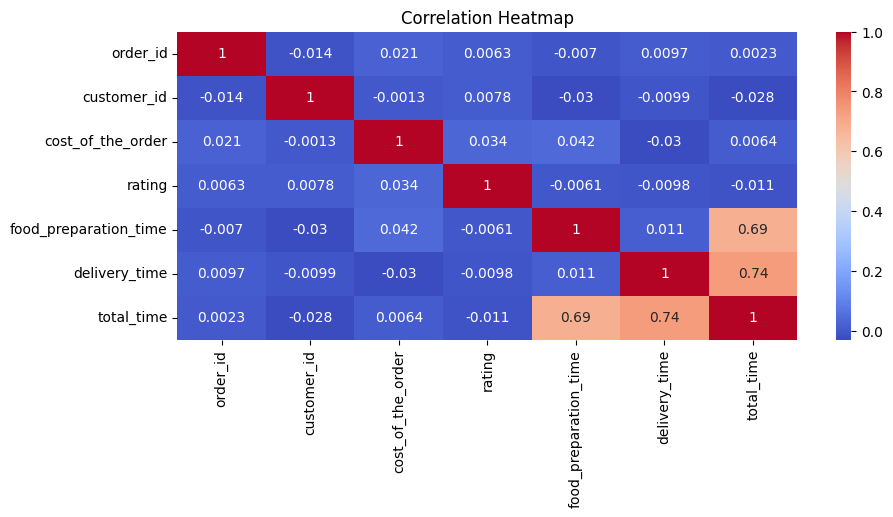

```python
# Write the code here
#Heatmap
plt.figure(figsize=(10,4))
# Select only numeric columns for correlation calculation
numeric_data = data.select_dtypes(include=np.number)
sns.heatmap(numeric_data.corr(), annot=True, cmap='coolwarm')
plt.title('Correlation Heatmap')
plt.show()
```

Categorical variable - Cuisine, Day of the week, Restaurant Names Numerical - Cost of order, food preparation time, delivery time and rating

The important variables for multi variate analysis are Cuisine, Day of the week,Cost of Order, Food Preparation Time , Delivery Time and Rating

Cuisine Vs Cost of Order

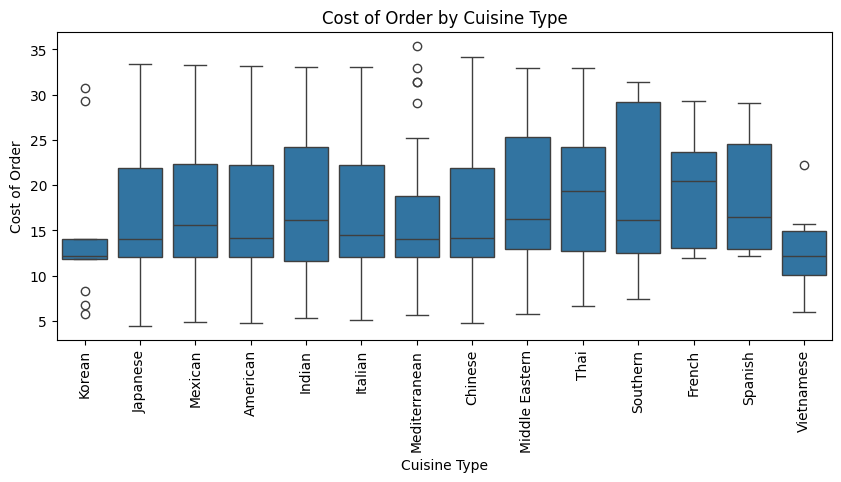

```python
#boxplot
plt.figure(figsize=(10,4))
sns.boxplot(x=data['cuisine_type'], y=data['cost_of_the_order'])
plt.xlabel('Cuisine Type')
plt.ylabel('Cost of Order')
plt.title('Cost of Order by Cuisine Type')
plt.xticks(rotation=90)
plt.show()
```

```python
data.groupby('cuisine_type')['cost_of_the_order'].agg(['mean', 'min', 'max', 'count', 'median']).sort_values(by='mean', ascending=False)
```

| cuisine_type | mean | min | max | count | median |
| --- | --- | --- | --- | --- | --- |
| French | 19.793889 | 11.98 | 29.25 | 18 | 20.470 |
| Southern | 19.300588 | 7.38 | 31.43 | 17 | 16.110 |
| Thai | 19.207895 | 6.69 | 32.93 | 19 | 19.350 |
| Spanish | 18.994167 | 12.13 | 29.10 | 12 | 16.520 |
| Middle Eastern | 18.820612 | 5.77 | 32.93 | 49 | 16.300 |
| Mexican | 16.933117 | 4.85 | 33.32 | 77 | 15.570 |
| Indian | 16.919726 | 5.34 | 33.03 | 73 | 16.150 |
| Italian | 16.418691 | 5.05 | 33.03 | 298 | 14.480 |
| American | 16.319829 | 4.71 | 33.18 | 584 | 14.120 |
| Chinese | 16.305209 | 4.75 | 34.19 | 215 | 14.120 |
| Japanese | 16.304532 | 4.47 | 33.37 | 470 | 14.070 |
| Mediterranean | 15.474783 | 5.67 | 35.41 | 46 | 13.995 |
| Korean | 14.001538 | 5.77 | 30.75 | 13 | 12.180 |
| Vietnamese | 12.882857 | 6.01 | 22.26 | 7 | 12.130 |

Observations:

French cuisine has the highest average order cost at $19.79

and Vietnamese has the lowest at $12.88

Largest sample is American and smallest is Vietnamese.

Most expensive order belong to Mediterranean.

Cuisine Vs Food Preparation Time

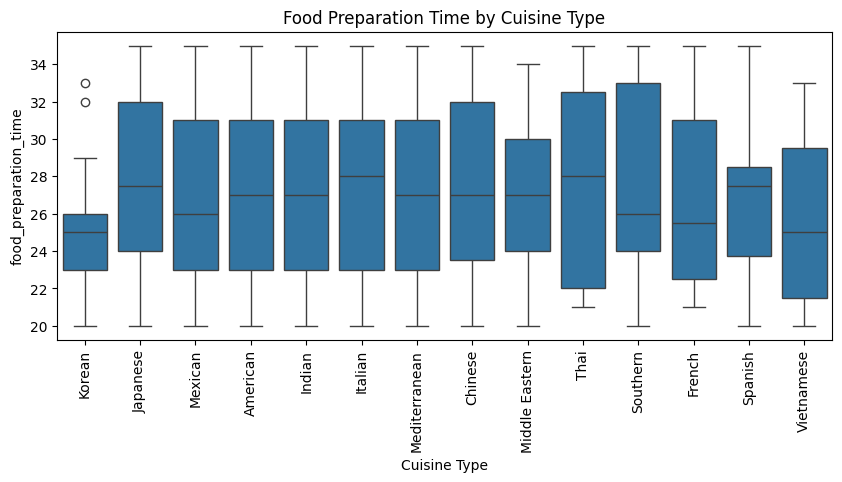

```python
#box plot
plt.figure(figsize=(10,4))
sns.boxplot(x=data['cuisine_type'], y=data['food_preparation_time'])
plt.xlabel('Cuisine Type')
# plt.ylabel('Food Preparation Time')
plt.title('Food Preparation Time by Cuisine Type')
plt.xticks(rotation=90)
plt.show()
```

```python
# Calculate count, min , max , mean and median
data.groupby('cuisine_type')['food_preparation_time'].agg(['mean', 'min', 'max', 'count', 'median']).sort_values(by='mean', ascending=False)
```

| cuisine_type | mean | min | max | count | median |
| --- | --- | --- | --- | --- | --- |
| Southern | 27.588235 | 20 | 35 | 17 | 26.0 |
| Chinese | 27.511628 | 20 | 35 | 215 | 27.0 |
| Japanese | 27.510638 | 20 | 35 | 470 | 27.5 |
| Italian | 27.483221 | 20 | 35 | 298 | 28.0 |
| American | 27.440068 | 20 | 35 | 584 | 27.0 |
| Thai | 27.315789 | 21 | 35 | 19 | 28.0 |
| Indian | 27.109589 | 20 | 35 | 73 | 27.0 |
| Mediterranean | 27.000000 | 20 | 35 | 46 | 27.0 |
| Spanish | 26.916667 | 20 | 35 | 12 | 27.5 |
| French | 26.888889 | 21 | 35 | 18 | 25.5 |
| Mexican | 26.727273 | 20 | 35 | 77 | 26.0 |
| Middle Eastern | 26.673469 | 20 | 34 | 49 | 27.0 |
| Vietnamese | 25.714286 | 20 | 33 | 7 | 25.0 |
| Korean | 25.461538 | 20 | 33 | 13 | 25.0 |

Observations:

The mean food preparation time is highly centralized from 25.5 minutes to 27.6 minutes.

Day of week Vs Delivery Time

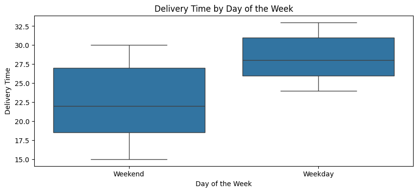

```python
#box plot
plt.figure(figsize=(10,4))
sns.boxplot(x=data['day_of_the_week'], y=data['delivery_time'])
plt.xlabel('Day of the Week')
plt.ylabel('Delivery Time')
plt.title('Delivery Time by Day of the Week')
plt.xticks
plt.show()
```

```python
# Calculate count, min, max, mean , median
data.groupby('day_of_the_week')['delivery_time'].agg(['mean', 'min', 'max', 'count', 'median']).sort_values(by='mean', ascending=False)
```

| day_of_the_week | mean | min | max | count | median |
| --- | --- | --- | --- | --- | --- |
| Weekday | 28.340037 | 24 | 33 | 547 | 28.0 |
| Weekend | 22.470022 | 15 | 30 | 1351 | 22.0 |

Observations:

Delivery time is substancially more on weekdays suggesting better logistics on weekends.

Cuisine Vs Rating

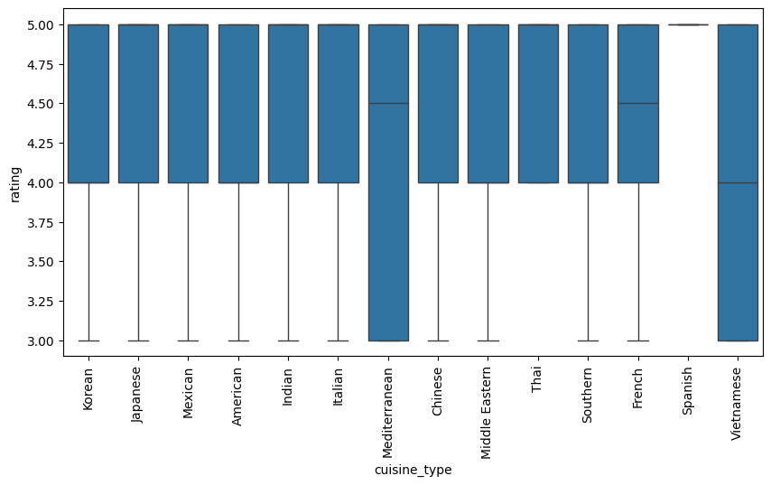

```python
plt.figure(figsize=(10,5))
sns.boxplot(data=data,x='cuisine_type',y='rating',showfliers=False) # turning off outliers
plt.xticks(rotation=90)
plt.show()
```

```python
# Calculate the percentage distribution of ratings for each cuisine with 3 , 4, 5, not given
cuisine_rating_percentage = pd.crosstab(data['cuisine_type'], data['rating_original'], normalize='index') * 100
print(cuisine_rating_percentage)
```

```
rating_original          3          4          5  Not given
cuisine_type
American         10.958904  22.260274  29.794521  36.986301
Chinese          11.162791  18.604651  32.093023  38.139535
French           11.111111  16.666667  27.777778  44.444444
Indian            6.849315  17.808219  43.835616  31.506849
Italian           9.395973  18.120805  30.201342  42.281879
Japanese          8.510638  19.361702  30.212766  41.914894
Korean           15.384615  30.769231  23.076923  30.769231
Mediterranean    19.565217  15.217391  34.782609  30.434783
Mexican           7.792208  20.779221  33.766234  37.662338
Middle Eastern   10.204082  32.653061  26.530612  30.612245
Southern          5.882353  41.176471  29.411765  23.529412
Spanish           0.000000   8.333333  41.666667  50.000000
Thai              0.000000  15.789474  31.578947  52.631579
Vietnamese       28.571429  14.285714  28.571429  28.571429
```

Observations:

Indian cuisine has highest 5 start ratings

Thai and Spanish have highest percentage of "Not given " ratings

Top Cuisines - American , Japanese and Italian ar not among the highest rated food and hence suggest improvements .

Numerical Vs Numerical

Rating Vs Delivery Time

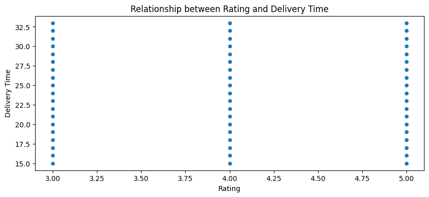

```python
#scatterplot
plt.figure(figsize=(10,4))
sns.scatterplot(x=data['rating'], y=data['delivery_time'])
plt.xlabel('Rating')
plt.ylabel('Delivery Time')
plt.title('Relationship between Rating and Delivery Time')
plt.show()
```

```python
# Calculate min, max, count , mean and median
data.groupby('rating_original')['delivery_time'].agg(['mean', 'min', 'max', 'count', 'median']).sort_values(by='mean', ascending=False)
```

| rating_original | mean | min | max | count | median |
| --- | --- | --- | --- | --- | --- |
| 3 | 24.558511 | 15 | 33 | 188 | 25.0 |
| 5 | 24.212585 | 15 | 33 | 588 | 25.0 |
| Not given | 24.173913 | 15 | 33 | 736 | 25.0 |
| 4 | 23.867876 | 15 | 33 | 386 | 24.0 |

Observations:

While is small but it coneys the idea and achieving 5 star rating needs more things.

Rating Vs Food Prep time

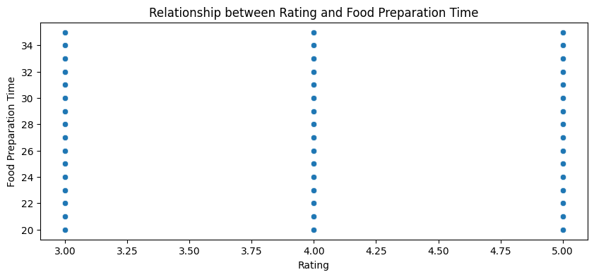

```python
# scatterplot
plt.figure(figsize=(10,4))
sns.scatterplot(x=data['rating'], y=data['food_preparation_time'])
plt.xlabel('Rating')
plt.ylabel('Food Preparation Time')
plt.title('Relationship between Rating and Food Preparation Time')
plt.show()
```

```python
# Calculate min , max, count , mean , median
data.groupby('rating_original')['food_preparation_time'].agg(['mean', 'min', 'max', 'count', 'median']).sort_values(by='mean', ascending=False)
```

| rating_original | mean | min | max | count | median |
| --- | --- | --- | --- | --- | --- |
| 3 | 27.430851 | 20 | 35 | 188 | 27.0 |
| 4 | 27.396373 | 20 | 35 | 386 | 27.0 |
| Not given | 27.357337 | 20 | 35 | 736 | 27.0 |
| 5 | 27.355442 | 20 | 35 | 588 | 27.5 |

Observations: Prep time is highly standarized and hence is not that accountable for ratings.

Rating Vs Cost of Order

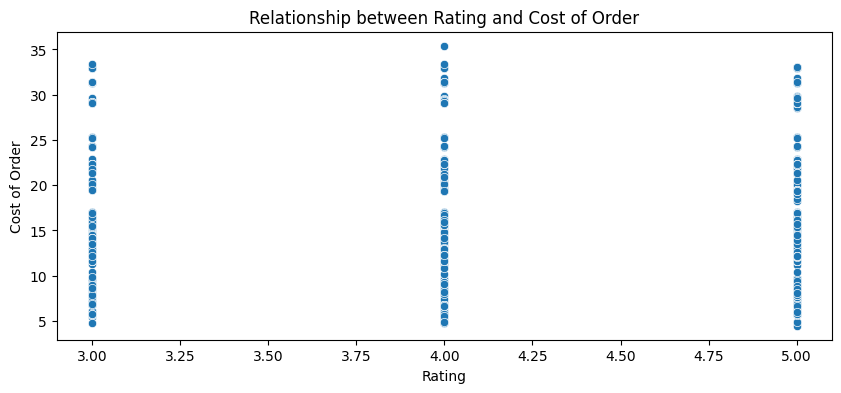

```python
# Scatter plot
plt.figure(figsize=(10,4))
sns.scatterplot(x=data['rating'], y=data['cost_of_the_order'])
plt.xlabel('Rating')
plt.ylabel('Cost of Order')
plt.title('Relationship between Rating and Cost of Order')
plt.show()
```

```python
# calculate min, max, count , mean , median
data.groupby('rating_original')['cost_of_the_order'].agg(['mean', 'min', 'max', 'count', 'median']).sort_values(by='mean', ascending=False)
```

| rating_original | mean | min | max | count | median |
| --- | --- | --- | --- | --- | --- |
| 5 | 16.965697 | 4.47 | 33.03 | 588 | 15.205 |
| 4 | 16.710337 | 4.75 | 35.41 | 386 | 14.160 |
| 3 | 16.223351 | 4.75 | 33.37 | 188 | 14.120 |
| Not given | 16.085340 | 4.66 | 34.19 | 736 | 14.070 |

Observations:

### **Question 13:** The company wants to provide a promotional offer in the advertisement of the restaurants. The condition to get the offer is that the restaurants must have a rating count of more than 50 and the average rating should be greater than 4. Find the restaurants fulfilling the criteria to get the promotional offer. [3 marks]

```python
data.info()
```

```
<class 'pandas.core.frame.DataFrame'>
RangeIndex: 1898 entries, 0 to 1897
Data columns (total 12 columns):
 #   Column                 Non-Null Count  Dtype
---  ------                 --------------  -----
 0   order_id               1898 non-null   int64
 1   customer_id            1898 non-null   int64
 2   restaurant_name        1898 non-null   object
 3   cuisine_type           1898 non-null   object
 4   cost_of_the_order      1898 non-null   float64
 5   day_of_the_week        1898 non-null   object
 6   rating                 1162 non-null   float64
 7   food_preparation_time  1898 non-null   int64
 8   delivery_time          1898 non-null   int64
 9   rating_original        1898 non-null   object
 10  total_time             1898 non-null   int64
 11  cost_category          1898 non-null   category
dtypes: category(1), float64(2), int64(5), object(4)
memory usage: 165.2+ KB
```

```python
# Filter the rated restaurants
data_rated = data[data['rating_original'] != 'Not given'].copy()

# Convert rating column from object to integer
data_rated['rating'] = data_rated['rating'].astype('int')

# Create a dataframe that contains the restaurant names with their rating counts
data_rating_count = data_rated.groupby(['restaurant_name'])['rating'].count().sort_values(ascending = False).reset_index()
data_rating_count.head()
```

|  | restaurant_name | rating |
| --- | --- | --- |
| 0 | Shake Shack | 133 |
| 1 | The Meatball Shop | 84 |
| 2 | Blue Ribbon Sushi | 73 |
| 3 | Blue Ribbon Fried Chicken | 64 |
| 4 | RedFarm Broadway | 41 |

```python
# Get the restaurant names that have rating count more than 50
data_rating_count = data_rating_count[data_rating_count['rating'] > 50]

# Filter to get the data of restaurants that have rating count more than 50
data_mean_4 = data_rated[data_rated['restaurant_name'].isin(data_rating_count['restaurant_name'])].copy()

# Group the restaurant names with their ratings and find the mean rating of each restaurant
data_mean_4_rating = data_mean_4.groupby(['restaurant_name'])['rating'].mean().sort_values(ascending = False).reset_index()

# filter for average rating greater than 4
data_avg_rating_greater_than_4 = data_mean_4_rating[data_mean_4_rating['rating'] > 4]
data_avg_rating_greater_than_4
```

|  | restaurant_name | rating |
| --- | --- | --- |
| 0 | The Meatball Shop | 4.511905 |
| 1 | Blue Ribbon Fried Chicken | 4.328125 |
| 2 | Shake Shack | 4.278195 |
| 3 | Blue Ribbon Sushi | 4.219178 |

#### Observations:

American and Japanese restaurants are performaing well in both customer volume and satisfaction.

Shake Shack stands out with 133 ratings stating its popularity.

Highest rated restaurant is The Meatball shop with average 4.5 rating.

### **Question 14:** The company charges the restaurant 25% on the orders having cost greater than 20 dollars and 15% on the orders having cost greater than 5 dollars. Find the net revenue generated by the company across all orders. [3 marks]

```python
#function to determine the revenue
def compute_rev(x):
    if x > 20:
        return x*0.25
    elif x > 5:
        return x*0.15
    else:
        return x*0

data['Revenue'] = data['cost_of_the_order'].apply(compute_rev)
data.head()
```

|  | order_id | customer_id | restaurant_name | cuisine_type | cost_of_the_order | day_of_the_week | rating | food_preparation_time | delivery_time | rating_original | total_time | cost_category | Revenue |
| --- | --- | --- | --- | --- | --- | --- | --- | --- | --- | --- | --- | --- | --- |
| 0 | 1477147 | 337525 | Hangawi | Korean | 30.75 | Weekend | NaN | 25 | 20 | Not given | 45 | 25+ | 7.6875 |
| 1 | 1477685 | 358141 | Blue Ribbon Sushi Izakaya | Japanese | 12.08 | Weekend | NaN | 25 | 23 | Not given | 48 | 0-20 | 1.8120 |
| 2 | 1477070 | 66393 | Cafe Habana | Mexican | 12.23 | Weekday | 5.0 | 23 | 28 | 5 | 51 | 0-20 | 1.8345 |
| 3 | 1477334 | 106968 | Blue Ribbon Fried Chicken | American | 29.20 | Weekend | 3.0 | 25 | 15 | 3 | 40 | 25+ | 7.3000 |
| 4 | 1478249 | 76942 | Dirty Bird to Go | American | 11.59 | Weekday | 4.0 | 25 | 24 | 4 | 49 | 0-20 | 1.7385 |

```python
# get the total revenue and print it
total_revenue = data['Revenue'].sum()
print(f"The net revenue generated by the company across all orders is ${total_revenue:.2f}")
```

```
The net revenue generated by the company across all orders is $6166.30
```

#### Observations:

Orders greater than 20 account for only 29.2 % but generate almost 60% of the company's total revenue.

70% of the orders are within 5-20 bracket which contribute 40.2 %.

### **Question 15:** The company wants to analyze the total time required to deliver the food. What percentage of orders take more than 60 minutes to get delivered from the time the order is placed? (The food has to be prepared and then delivered.) [2 marks]

```python
# Write the code here
data['total_delivery_time'] = data['food_preparation_time'] + data['delivery_time']
high_delivery_time_orders = data[data['total_delivery_time'] > 60]
high_delivery_time_percentage = (len(high_delivery_time_orders) / len(data)) * 100
high_delivery_time_percentage
print(f"The percentage of orders taking more than 60 minutes to get delivered is {high_delivery_time_percentage:.2f}%")
```

```
The percentage of orders taking more than 60 minutes to get delivered is 10.54%
```

### **Question 16:** The company wants to analyze the delivery time of the orders on weekdays and weekends. How does the mean delivery time vary during weekdays and weekends? [2 marks]

```python
# Write the code here
delivery_time_by_day = data.groupby('day_of_the_week')['delivery_time'].mean()
print("Mean delivery time by day of the week:")
print(delivery_time_by_day)
```

```
Mean delivery time by day of the week:
day_of_the_week
Weekday    28.340037
Weekend    22.470022
Name: delivery_time, dtype: float64
```

#### Observations:

Weekends are faster about 6 minutes shorter despite majority (1,351) of orders on weekends.

weekdays are more predictable and consistent.

### Conclusion and Recommendations

### **Question 17:** What are your conclusions from the analysis? What recommendations would you like to share to help improve the business? (You can use cuisine type and feedback ratings to drive your business recommendations.) [6 marks]

### Conclusions:

- Revenue model is highly leveraged on high-value orders(<$20). Only 29.2 % of orders(555) generate 59.8% of the total commission revenue. The 15% commission bracket is high-volume but lower-yield.
- The company is significantly faster at delivering orders on the weekend(average 22.47 mins) despite the much higher volume of orders. Weekday deliveries are ~ 6 mins slower( average 28.34) but are highly consistent.
- The vast majority of orders(nearly 90%) are delivered within the indutry benchmark of 60 minutes. However, 10.54%(200 orders) exceed the 60 minute mark, representing the primary friction point in customer satisfaction regarding speed.
- American ( 171 orderd) and Japanese ( 122 orders) cuisines are top 2 sources of high-value orders(>$20), making them critical partners for revenue generation and retention.

### Recommendations:

- Introduce Tiers for Low-value orders: Implement a small flat fee(e.g. $1 or $2) on orders <= $5 instead of 0% commission. This caotures some revenue from the currentlt non-revenue generating transactions(9 orders) while keeping relative cost low for the customer/restaurant or introduce a minimum basket for free delivery/service.
- Incentivize High-Value Cuisines: Run targeted co-marketing campaingns, offer reduced prep-time incentives, or provide premium placement for restaurants specializing in the Top 4 revennues cuisines( American , Japanese, Italian, Chinese) to further increase their order volume and average basket size.
- Leverage Restuarant Ratings:

American and Japanese restaurants are both high in volume for rating and satisfactory as well. Incentivize and spend more investment on these restaurants.

- Give Incentives to provide rating 38.8% people did not rate . This should be evaluated and provide incentives to customer so that company can get more better insights.
- Optimize weekday Logistics

Since weekday develivers are ~ 6 mns slower, analyze weekday delivery routes and driver assignments during peak hours,

- Reduce Delivery time

- Establish Customer Communication Protocol for Delays For any order projected to exceed 60 minutes, the customer must be informed about the issue and a small future use discont code.
- Standardize Weekend Delivery